# BNI assessment for plant root exudates demonstration

Alex Kanellopoulos

2024-08-22

Brief description: This is a script that includes analyses for the assessment of BNI activity of different plant root exudates. In the dataset, I have included 44 and 33 root exudates from equal different genotypes of two different plant species. These exudates were screened for BNI activity against 4 AOM strains, belonging in 2 different AOM Domains, and the AOI (Ammonia Oxidation Inhibition %) is given. The analyses include descriptive statistics for the BNI activity, followed by a section for producing barplots for the different exudates across all 4 AOM strains. Finally, I have included data visualisation in a heatmap format and investigation of inhibitory profiles using a PCA.

Step 1: Let’s see all the necessary packages needed for the analysis and load them. If they are not installed, we will install them first.

```r
# Here we store the necessary packages in the necessary_packages variable
necessary_packages <- c("readxl","dplyr","agricolae", "tibble", "ggplot2","ggpubr", "scales","rstatix","ComplexHeatmap","dendextend","vegan","factoextra")

# Here we check if the necessary packages are installed. If not, R installs them
if (!requireNamespace(necessary_packages, quietly = TRUE)) {
  install.packages(necessary_packages)
}

# Here, for every package included in the necessary_packages variable, R will load it. The character.only = TRUE ensures that library() will try to interpret the package names as characters (as it needs for it to work)
for (package in necessary_packages) {
  library(package, character.only = TRUE)
}
```

Step 2: We will load the data. We need two different data formats. The first format will be used for the inhibition plots and the descriptive statistics. The second format will be used for the data visualisation (heatmap, PCA)

See here the first format

```
## # A tibble: 12 × 7
##    Exudate Strain   Domain     AOI  Mean St.Error Plant
##    <chr>   <chr>    <chr>    <dbl> <dbl>    <dbl> <chr>
##  1 A1      Strain A Domain A  7.26  9.98    1.11  Plant A
##  2 A1      Strain A Domain A 11.5  NA      NA     Plant A
##  3 A1      Strain A Domain A 11.2  NA      NA     Plant A
##  4 A2      Strain A Domain A 34.0  32.3     0.756 Plant A
##  5 A2      Strain A Domain A 32.1  NA      NA     Plant A
##  6 A2      Strain A Domain A 30.9  NA      NA     Plant A
##  7 A3      Strain A Domain A 30.4  32.4     3.11  Plant A
##  8 A3      Strain A Domain A 27.1  NA      NA     Plant A
##  9 A3      Strain A Domain A 39.8  NA      NA     Plant A
## 10 A4      Strain A Domain A 19.5  20.7     0.499 Plant A
## 11 A4      Strain A Domain A 21.5  NA      NA     Plant A
## 12 A4      Strain A Domain A 21.2  NA      NA     Plant A
```

See here the second format

```
## # A tibble: 12 × 6
##    Exudate `Strain A` `Strain B` `Strain C` `Strain D` Plant
##    <chr>        <dbl>      <dbl>      <dbl>      <dbl> <chr>
##  1 A1            9.98       4.92     14.8        42.4  Plant A
##  2 A2           32.3       23.7       4.75       19.1  Plant A
##  3 A3           32.4       18.1      31.3        33.9  Plant A
##  4 A4           20.7       18.4     -10.9        20.0  Plant A
##  5 A5           16.0       11.0      10.8        41.9  Plant A
##  6 A6           14.4       14.4       5.29       18.9  Plant A
##  7 A7           30.2       16.6       3.39        7.74 Plant A
##  8 A8           27.1       16.1     -13.7         6.36 Plant A
##  9 A9           31.1       27.9      -4.74       35.0  Plant A
## 10 A10          29.5       22.8      20.6        54.3  Plant A
## 11 A11          11.3       11.9       8.68       55.5  Plant A
## 12 A12          17.3       15.9       0.285      52.4  Plant A
```

**Section 1 : Inhibition Plots**

Step 1: Let’s import the data for the inhibition plots

```r
# Data import
library(readxl)
data_inhibition_plots <- read_excel("data.xlsx", sheet = 1, col_names = TRUE)

# We can change the names of the columns to more R-friendly names
names(data_inhibition_plots) <- c("Exudate", "Strain", "Domain", "AOI", "Mean", "St.Error", "Plant")

#Let's view the data
glimpse(data_inhibition_plots)
```

```
## Rows: 921
## Columns: 7
## $ Exudate  <chr> "A1", "A1", "A1", "A2", "A2", "A2", "A3", "A3", "A3", "A4", "…
## $ Strain   <chr> "Strain A", "Strain A", "Strain A", "Strain A", "Strain A", "…
## $ Domain   <chr> "Domain A", "Domain A", "Domain A", "Domain A", "Domain A", "…
## $ AOI      <dbl> 7.261725, 11.497731, 11.195159, 34.039334, 32.072617, 30.8623…
## $ Mean     <dbl> 9.984871, NA, NA, 32.324760, NA, NA, 32.425618, NA, NA, 20.72…
## $ St.Error <dbl> 1.1140051, NA, NA, 0.7558691, NA, NA, 3.1064481, NA, NA, 0.49…
## $ Plant    <chr> "Plant A", "Plant A", "Plant A", "Plant A", "Plant A", "Plant…
```

```r
# We will store the names of the different root exudates
REs <- as.factor(levels(as.factor(data_inhibition_plots$Exudate)))
REs
```

```
##  [1] A1  A10 A11 A12 A13 A14 A15 A16 A17 A18 A19 A2  A20 A21 A22 A23 A24 A25 A26
## [20] A27 A28 A29 A3  A30 A31 A32 A33 A34 A35 A36 A37 A38 A39 A4  A40 A41 A42 A43
## [39] A44 A5  A6  A7  A8  A9  B1  B10 B11 B12 B13 B14 B15 B17 B19 B20 B21 B24 B27
## [58] B28 B3  B30 B31 B32 B33 B34 B35 B36 B37 B38 B39 B4  B40 B42 B44 B5  B6  B7
## [77] B9
## 77 Levels: A1 A10 A11 A12 A13 A14 A15 A16 A17 A18 A19 A2 A20 A21 A22 ... B9
```

Step 2: Here we will split the data per root exudate into different data frames

```r
# We will create an empty list that we will fill with all the different data frames
dataframe_list_REs <- list()

# This for() loop will create the separate data frames
for (i in 1:summary(levels(REs))[[1]]) {
  data_inh <- data.frame(filter(data_inhibition_plots, Exudate == REs[i]))
  dataframe_name <- paste("df","inhibition",REs[i], sep = "_")
  dataframe_list_REs[[dataframe_name]] <- data_inh
}

# Let's see how many dataframes are inside the list
nrow(as.matrix(summary(dataframe_list_REs)))
```

```
## [1] 77
```

```r
# Let's see which dataframes are inside the list
rownames(as.matrix(summary(dataframe_list_REs)))
```

```
##  [1] "df_inhibition_A1"  "df_inhibition_A10" "df_inhibition_A11"
##  [4] "df_inhibition_A12" "df_inhibition_A13" "df_inhibition_A14"
##  [7] "df_inhibition_A15" "df_inhibition_A16" "df_inhibition_A17"
## [10] "df_inhibition_A18" "df_inhibition_A19" "df_inhibition_A2"
## [13] "df_inhibition_A20" "df_inhibition_A21" "df_inhibition_A22"
## [16] "df_inhibition_A23" "df_inhibition_A24" "df_inhibition_A25"
## [19] "df_inhibition_A26" "df_inhibition_A27" "df_inhibition_A28"
## [22] "df_inhibition_A29" "df_inhibition_A3"  "df_inhibition_A30"
## [25] "df_inhibition_A31" "df_inhibition_A32" "df_inhibition_A33"
## [28] "df_inhibition_A34" "df_inhibition_A35" "df_inhibition_A36"
## [31] "df_inhibition_A37" "df_inhibition_A38" "df_inhibition_A39"
## [34] "df_inhibition_A4"  "df_inhibition_A40" "df_inhibition_A41"
## [37] "df_inhibition_A42" "df_inhibition_A43" "df_inhibition_A44"
## [40] "df_inhibition_A5"  "df_inhibition_A6"  "df_inhibition_A7"
## [43] "df_inhibition_A8"  "df_inhibition_A9"  "df_inhibition_B1"
## [46] "df_inhibition_B10" "df_inhibition_B11" "df_inhibition_B12"
## [49] "df_inhibition_B13" "df_inhibition_B14" "df_inhibition_B15"
## [52] "df_inhibition_B17" "df_inhibition_B19" "df_inhibition_B20"
## [55] "df_inhibition_B21" "df_inhibition_B24" "df_inhibition_B27"
## [58] "df_inhibition_B28" "df_inhibition_B3"  "df_inhibition_B30"
## [61] "df_inhibition_B31" "df_inhibition_B32" "df_inhibition_B33"
## [64] "df_inhibition_B34" "df_inhibition_B35" "df_inhibition_B36"
## [67] "df_inhibition_B37" "df_inhibition_B38" "df_inhibition_B39"
## [70] "df_inhibition_B4"  "df_inhibition_B40" "df_inhibition_B42"
## [73] "df_inhibition_B44" "df_inhibition_B5"  "df_inhibition_B6"
## [76] "df_inhibition_B7"  "df_inhibition_B9"
```

Step 3: Here we will create the legend order for all the inhibition plots. We need the order to be as follows: Strain A, Strain B, Strain C, Strain D

```r
# We will create the legend order
legend_order <- c("Strain A","Strain B","Strain C","Strain D")
```

Step 4: We will perform Kruskal - Wallis tests with a post - hoc test to differentiate the inhibitory activity of each root exudate against the 4 different AOM strains

```r
library(agricolae)
library(tibble)

# We will create two empty lists to be filled later. One will contain the kruskal - wallis reports and the second one will contain the groupings, in order for them to be assigned over the barplots later
kruskals <- list()
kruskals_groups <- list()

# The for() loop will perform the test for each data frame in the list we created earlier and will apply the Bonferroni method for p - value adjustment. It will store the reports in the first list.
# Then it will sort the groupings results by the legend order instead of the value, so the letters can be properly placed above the correct bar in the barplot.
for (i in 1:nrow(as.matrix(summary(dataframe_list_REs)))) {
  kruskal_inhibition <- with(data = dataframe_list_REs[[i]], kruskal(AOI, Strain, p.adj = "bonferroni", group = T, alpha = 0.05))
  kruskal_name <- paste("kruskal",REs[i], sep = "_")
  kruskals[[kruskal_name]] <- kruskal_inhibition

  treatment_order <- legend_order
  kruskal_results <- data.frame(kruskal_inhibition$groups)
  kruskal_results <- rownames_to_column(kruskal_results, var = "Strain")
  kruskal_results$Strain <- factor(kruskal_results$Strain, levels = treatment_order)
  kruskal_results <- kruskal_results[order(kruskal_results$Strain), ]
  kruskal_results_name <- paste("kruskal","groups", REs[i], sep = "_")
  kruskals_groups[[kruskal_results_name]] <- kruskal_results
}

# Let's see which dataframes are inside each list
rownames(as.matrix(summary(kruskals)))
```

```
##  [1] "kruskal_A1"  "kruskal_A10" "kruskal_A11" "kruskal_A12" "kruskal_A13"
##  [6] "kruskal_A14" "kruskal_A15" "kruskal_A16" "kruskal_A17" "kruskal_A18"
## [11] "kruskal_A19" "kruskal_A2"  "kruskal_A20" "kruskal_A21" "kruskal_A22"
## [16] "kruskal_A23" "kruskal_A24" "kruskal_A25" "kruskal_A26" "kruskal_A27"
## [21] "kruskal_A28" "kruskal_A29" "kruskal_A3"  "kruskal_A30" "kruskal_A31"
## [26] "kruskal_A32" "kruskal_A33" "kruskal_A34" "kruskal_A35" "kruskal_A36"
## [31] "kruskal_A37" "kruskal_A38" "kruskal_A39" "kruskal_A4"  "kruskal_A40"
## [36] "kruskal_A41" "kruskal_A42" "kruskal_A43" "kruskal_A44" "kruskal_A5"
## [41] "kruskal_A6"  "kruskal_A7"  "kruskal_A8"  "kruskal_A9"  "kruskal_B1"
## [46] "kruskal_B10" "kruskal_B11" "kruskal_B12" "kruskal_B13" "kruskal_B14"
## [51] "kruskal_B15" "kruskal_B17" "kruskal_B19" "kruskal_B20" "kruskal_B21"
## [56] "kruskal_B24" "kruskal_B27" "kruskal_B28" "kruskal_B3"  "kruskal_B30"
## [61] "kruskal_B31" "kruskal_B32" "kruskal_B33" "kruskal_B34" "kruskal_B35"
## [66] "kruskal_B36" "kruskal_B37" "kruskal_B38" "kruskal_B39" "kruskal_B4"
## [71] "kruskal_B40" "kruskal_B42" "kruskal_B44" "kruskal_B5"  "kruskal_B6"
## [76] "kruskal_B7"  "kruskal_B9"
```

```r
rownames(as.matrix(summary(kruskals_groups)))
```

```
##  [1] "kruskal_groups_A1"  "kruskal_groups_A10" "kruskal_groups_A11"
##  [4] "kruskal_groups_A12" "kruskal_groups_A13" "kruskal_groups_A14"
##  [7] "kruskal_groups_A15" "kruskal_groups_A16" "kruskal_groups_A17"
## [10] "kruskal_groups_A18" "kruskal_groups_A19" "kruskal_groups_A2"
## [13] "kruskal_groups_A20" "kruskal_groups_A21" "kruskal_groups_A22"
## [16] "kruskal_groups_A23" "kruskal_groups_A24" "kruskal_groups_A25"
## [19] "kruskal_groups_A26" "kruskal_groups_A27" "kruskal_groups_A28"
## [22] "kruskal_groups_A29" "kruskal_groups_A3"  "kruskal_groups_A30"
## [25] "kruskal_groups_A31" "kruskal_groups_A32" "kruskal_groups_A33"
## [28] "kruskal_groups_A34" "kruskal_groups_A35" "kruskal_groups_A36"
## [31] "kruskal_groups_A37" "kruskal_groups_A38" "kruskal_groups_A39"
## [34] "kruskal_groups_A4"  "kruskal_groups_A40" "kruskal_groups_A41"
## [37] "kruskal_groups_A42" "kruskal_groups_A43" "kruskal_groups_A44"
## [40] "kruskal_groups_A5"  "kruskal_groups_A6"  "kruskal_groups_A7"
## [43] "kruskal_groups_A8"  "kruskal_groups_A9"  "kruskal_groups_B1"
## [46] "kruskal_groups_B10" "kruskal_groups_B11" "kruskal_groups_B12"
## [49] "kruskal_groups_B13" "kruskal_groups_B14" "kruskal_groups_B15"
## [52] "kruskal_groups_B17" "kruskal_groups_B19" "kruskal_groups_B20"
## [55] "kruskal_groups_B21" "kruskal_groups_B24" "kruskal_groups_B27"
## [58] "kruskal_groups_B28" "kruskal_groups_B3"  "kruskal_groups_B30"
## [61] "kruskal_groups_B31" "kruskal_groups_B32" "kruskal_groups_B33"
## [64] "kruskal_groups_B34" "kruskal_groups_B35" "kruskal_groups_B36"
## [67] "kruskal_groups_B37" "kruskal_groups_B38" "kruskal_groups_B39"
## [70] "kruskal_groups_B4"  "kruskal_groups_B40" "kruskal_groups_B42"
## [73] "kruskal_groups_B44" "kruskal_groups_B5"  "kruskal_groups_B6"
## [76] "kruskal_groups_B7"  "kruskal_groups_B9"
```

Step 5: Here we will create the inhibition barplots

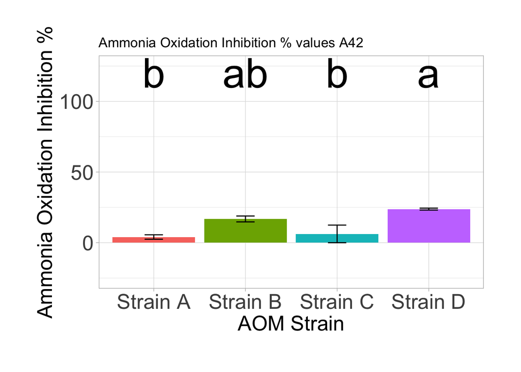

```r
library(ggplot2)

# We will create an empty list to store all plots
inhibition_barplots <- list()

# The for() loop will create the plots and store them in the list
for (i in 1:nrow(as.matrix(summary(dataframe_list_REs)))) {

  # This will sort them correctly in order to avoid mistakes in the plots
  dataframe_list_REs[[i]]$Exudate <- factor(dataframe_list_REs[[i]]$Exudate, levels = legend_order)
      inhibition_plot_temp <- ggplot(filter(dataframe_list_REs[[i]], !is.na(Mean)), aes(x = Strain, y = Mean)) +
        geom_col(aes(x = Strain, y = Mean, fill = Strain)) +
        theme_light() +
        labs(title = paste("Ammonia Oxidation Inhibition % values", REs[i]), x = "AOM Strain", y = "Ammonia Oxidation Inhibition %") +
        theme(axis.title = element_text(size = 20), axis.text = element_text(size = 20), axis.text.x = element_text(angle = 0), legend.text = element_text(), legend.title = element_text(size = 20), legend.position = "none") + geom_errorbar(aes(ymin = Mean - St.Error, ymax = Mean + St.Error, width = 0.2)) +
        scale_x_discrete(limits = legend_order) +
        ylim(-25,125) +
        geom_text(data = kruskals_groups[[i]], aes(label = groups, y = 110, vjust = -0), size = 14) +
        theme(plot.margin = unit(c(0.5, 0.5, 0.5, 0.5), "inches"))

  inhibition_plot_name <- paste("inhibition","plot",REs[i],sep = "_")
  inhibition_barplots[inhibition_plot_name] <- list(plot = inhibition_plot_temp)
}

# Let's see one inhibition barplot
inhibition_barplots[37]
```

Step 6: We will generate a .pdf file with all the plots

```r
#### Generate the .pdf file ----
cairo_pdf("RE_Inhibition plots_all strains.pdf", height = 8, width = 8, onefile = T)
for (i in 1:nrow(as.matrix(summary(inhibition_barplots)))) {
  print(inhibition_barplots[i])
}
dev.off()

graphics.off()
```

**Section 2 : Descriptive statistics**

Step 1: We will use the data in the same format as above. we can clear the environment and re-import the data

```r
# Clear environment
rm(list = ls())

# Import the data
library(readxl)
data_statistics <- read_xlsx("data.xlsx", sheet = 1)

# We can remove rows with no AOI data in order not to mess with the analysis
library(dplyr)
data_statistics <- filter(data_statistics, !is.na(AOI))
```

Step 2: We will investigate the distribution of the AOI values in order to decide whether to proceed with parametric or non - parametric tests. If the p-value is lower than the threshold, we debunk the hypothesis that data in each group are normally distributed and perform non-parametric tests

```r
# Shapiro - Wilk test for different domains
shapiro_domain_A <- shapiro.test(filter(data_statistics, Domain == "Domain A")$AOI)
shapiro_domain_B <- shapiro.test(filter(data_statistics, Domain == "Domain B")$AOI)

shapiro_domain_A
```

```
##
##  Shapiro-Wilk normality test
##
## data:  filter(data_statistics, Domain == "Domain A")$AOI
## W = 0.86833, p-value < 2.2e-16
```

```r
shapiro_domain_B
```

```
##
##  Shapiro-Wilk normality test
##
## data:  filter(data_statistics, Domain == "Domain B")$AOI
## W = 0.93966, p-value = 1.207e-12
```

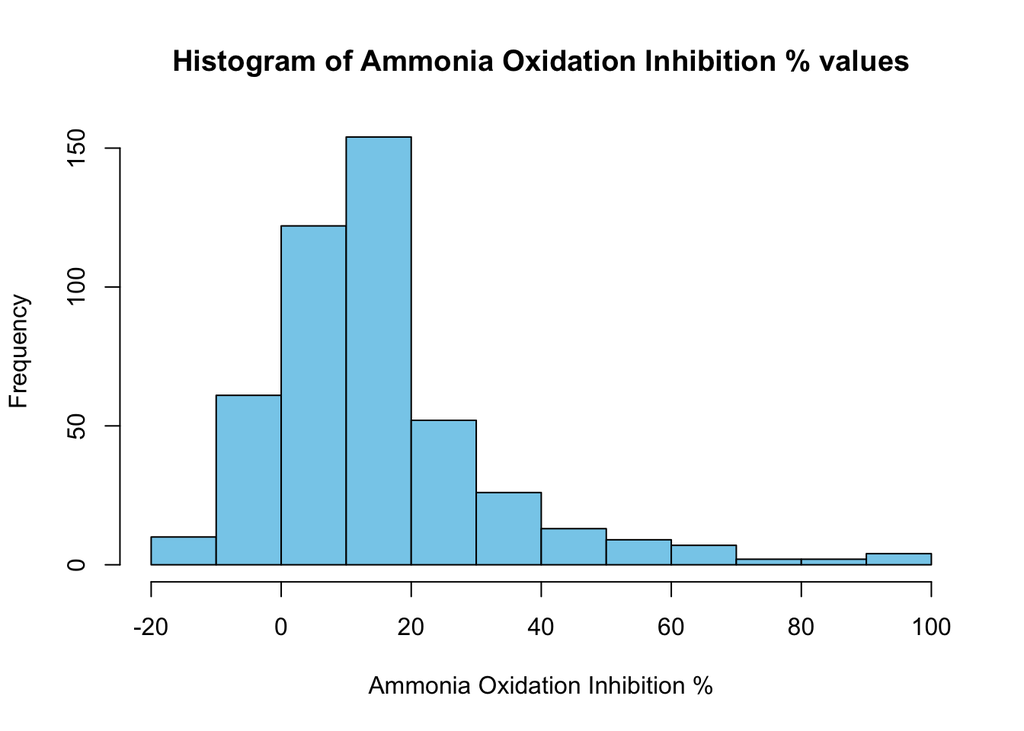

```r
  # We can create histograms (indicatevly for the two domains)
AOI_histogram_domain_A <- hist(filter(data_statistics, Domain == "Domain A")$AOI, breaks = 9, main = "Histogram of Ammonia Oxidation Inhibition % values", xlab = "Ammonia Oxidation Inhibition %", col = "skyblue")
```

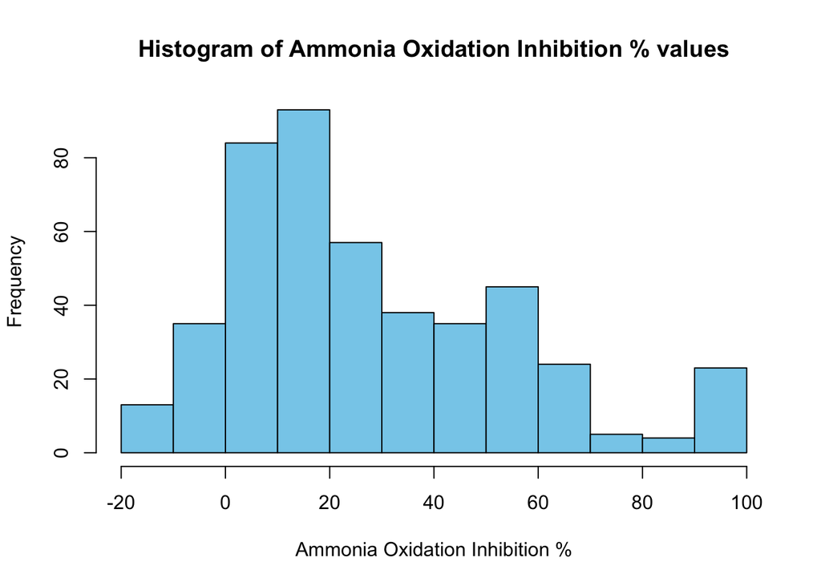

```r
AOI_histogram_domain_B <- hist(filter(data_statistics, Domain == "Domain B")$AOI, breaks = 9, main = "Histogram of Ammonia Oxidation Inhibition % values", xlab = "Ammonia Oxidation Inhibition %", col = "skyblue")
```

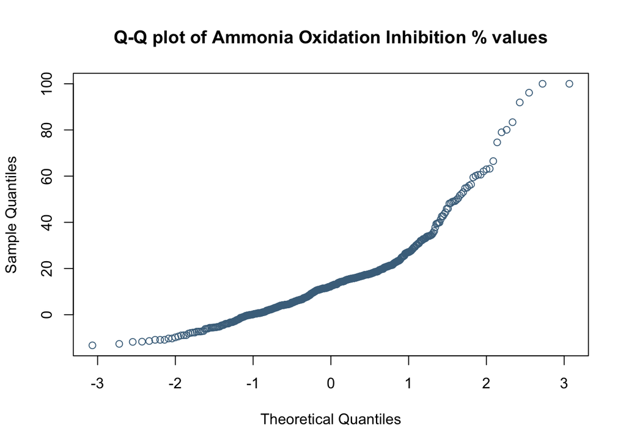

```r
  # We can also utilise Q-Q plots (indicatevly for the two domains)
qq_plot_domain_A <- qqnorm(filter(data_statistics, Domain == "Domain A")$AOI, main = "Q-Q plot of Ammonia Oxidation Inhibition % values", col = "skyblue4")
```

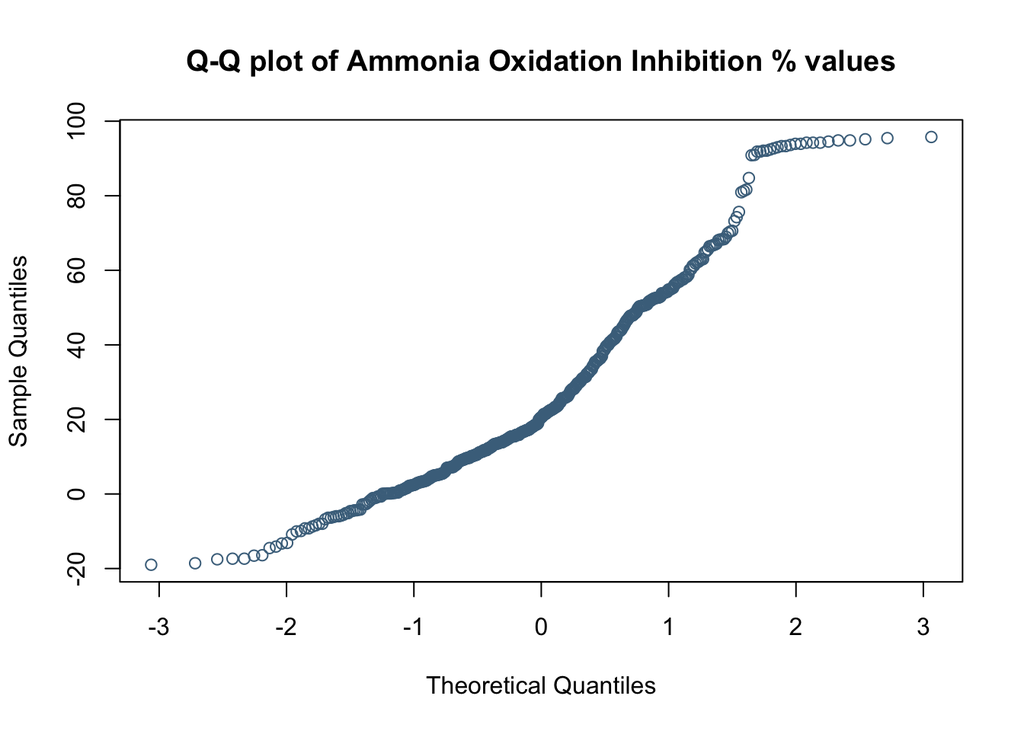

```r
qq_plot_domain_B <- qqnorm(filter(data_statistics, Domain == "Domain B")$AOI, main = "Q-Q plot of Ammonia Oxidation Inhibition % values", col = "skyblue4")
```

```r
# Shapiro - Wilk test for different strains
shapiro_strain_A <- shapiro.test(filter(data_statistics, Strain == "Strain A")$AOI)
shapiro_strain_B <- shapiro.test(filter(data_statistics, Strain == "Strain B")$AOI)
shapiro_strain_C <- shapiro.test(filter(data_statistics, Strain == "Strain C")$AOI)
shapiro_strain_D <- shapiro.test(filter(data_statistics, Strain == "Strain D")$AOI)

shapiro_strain_A
```

```
##
##  Shapiro-Wilk normality test
##
## data:  filter(data_statistics, Strain == "Strain A")$AOI
## W = 0.88365, p-value = 2.492e-12
```

```r
shapiro_strain_B
```

```
##
##  Shapiro-Wilk normality test
##
## data:  filter(data_statistics, Strain == "Strain B")$AOI
## W = 0.86474, p-value = 2.007e-13
```

```r
shapiro_strain_C
```

```
##
##  Shapiro-Wilk normality test
##
## data:  filter(data_statistics, Strain == "Strain C")$AOI
## W = 0.86, p-value = 1.109e-13
```

```r
shapiro_strain_D
```

```
##
##  Shapiro-Wilk normality test
##
## data:  filter(data_statistics, Strain == "Strain D")$AOI
## W = 0.93903, p-value = 4.445e-08
```

```r
# Shapiro - Wilk test for different plants
shapiro_plant_A <- shapiro.test(filter(data_statistics, Plant == "Plant A")$AOI)
shapiro_plant_B <- shapiro.test(filter(data_statistics, Plant == "Plant B")$AOI)

shapiro_plant_A
```

```
##
##  Shapiro-Wilk normality test
##
## data:  filter(data_statistics, Plant == "Plant A")$AOI
## W = 0.91101, p-value < 2.2e-16
```

```r
shapiro_plant_B
```

```
##
##  Shapiro-Wilk normality test
##
## data:  filter(data_statistics, Plant == "Plant B")$AOI
## W = 0.91744, p-value = 7.4e-14
```

Step 3: We will first compare the mean AOI values between the 2 Domains of AOM strains

```r
# We will group the data based on the domain and investigate the means
library(dplyr)
data_grouped_domain <- group_by(filter(data_statistics, !is.na(AOI)), Domain)
summarise(data_grouped_domain, mean_AOI = mean(AOI))
```

```
## # A tibble: 2 × 2
##   Domain   mean_AOI
##   <chr>       <dbl>
## 1 Domain A     14.8
## 2 Domain B     27.4
```

```r
# We will compute a Wilcoxon test
library(rstatix)
wilcox_test(data_statistics, AOI ~ Domain)
```

```
## # A tibble: 1 × 7
##   .y.   group1   group2      n1    n2 statistic        p
## * <chr> <chr>    <chr>    <int> <int>     <dbl>    <dbl>
## 1 AOI   Domain A Domain B   462   456     76079 3.25e-13
```

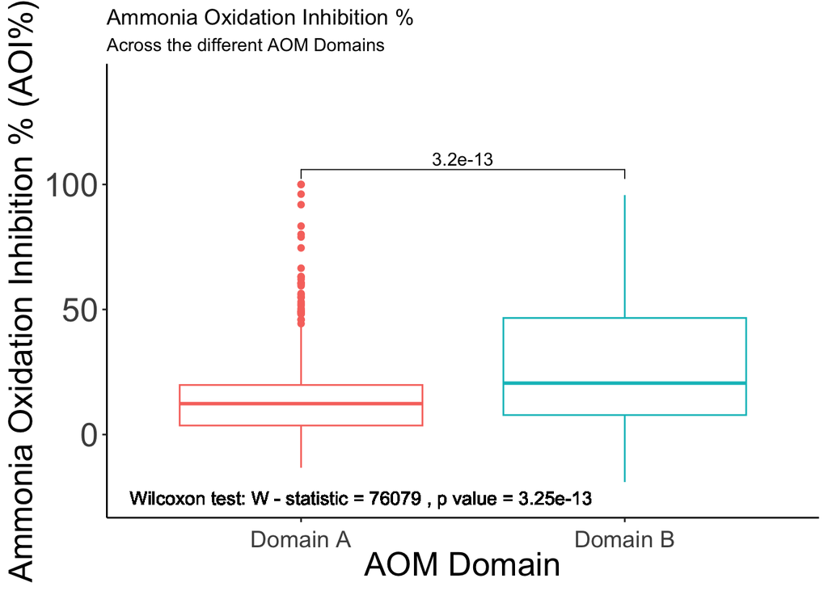

```r
# We will generate a box - plot and incorporate the result of the Wilcoxon test
library(ggplot2)
library(ggpubr)

AOIs_boxplot_domain <- ggplot(data_statistics, aes(x = Domain, y = AOI, col = Domain)) +
  geom_boxplot(aes(colour = Domain)) +
  theme_classic() +
  labs(title = "Ammonia Oxidation Inhibition %", subtitle = "Across the different AOM Domains", x = "AOM Domain", y = "Ammonia Oxidation Inhibition % (AOI%)") +
  theme(axis.title = element_text(size = 20), axis.text.y = element_text(size = 20), axis.text.x = element_text(size = 14, angle = 0, vjust = 0), legend.text = element_text(size = 20), legend.title = element_text(size = 20), legend.position = "none") +
  ylim(-25,140) +
  geom_text(x = -Inf, y = -Inf, label = paste("Wilcoxon test: W - statistic =", round(wilcox_test(data_statistics, AOI ~ Domain)$statistic,2), ", p value =", wilcox_test(data_statistics, AOI ~ Domain)$p), vjust = -1, hjust = -0.05, colour = "black", size = 4) +
  stat_compare_means(method = "wilcox.test", label = "p.format", comparisons = list(c("Domain A","Domain B")))

AOIs_boxplot_domain
```

```r
cairo_pdf("AOI values boxplot_domain.pdf", height = 8, width = 7)
print(AOIs_boxplot_domain)
dev.off()
```

Step 4: We will now compare the mean AOI values between the 4 AOM strains

```r
# We will group the data based on the domain and investigate the means
library(dplyr)
data_grouped_strain <- group_by(filter(data_statistics, !is.na(AOI)), Strain)
summarise(data_grouped_strain, mean_AOI = mean(AOI))
```

```
## # A tibble: 4 × 2
##   Strain   mean_AOI
##   <chr>       <dbl>
## 1 Strain A     16.1
## 2 Strain B     13.5
## 3 Strain C     22.5
## 4 Strain D     32.5
```

```r
# We will compute a Kruskal - Wallis test and sort the groups as we did above for the inhibition barplots, so they appear correctly over the corresponding box

library(rstatix)
kruskal_test(data_statistics, AOI ~ Strain)
```

```
## # A tibble: 1 × 6
##   .y.       n statistic    df        p method
## * <chr> <int>     <dbl> <int>    <dbl> <chr>
## 1 AOI     918      115.     3 1.10e-24 Kruskal-Wallis
```

```r
library(agricolae)
kruskal_AOIs_Strain <- with(data = data_statistics, kruskal(AOI, Strain, p.adj = "bonferroni", group = T, alpha = 0.05))
kruskal_AOIs_Strain$groups
```

```
##               AOI groups
## Strain D 622.2133      a
## Strain C 427.6667      b
## Strain A 401.9913      b
## Strain B 390.3550      b
```

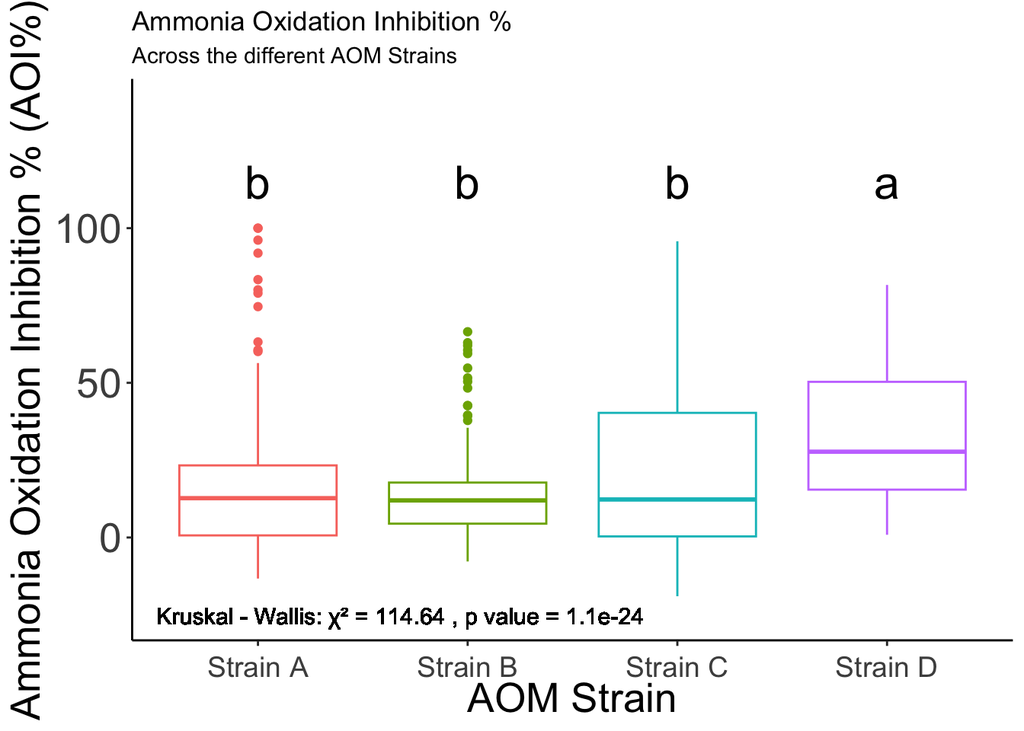

```r
library(tibble)
legend_order <- c("Strain A","Strain B","Strain C","Strain D")

kruskal_results <- data.frame(kruskal_AOIs_Strain$groups)
kruskal_results <- rownames_to_column(kruskal_results, var = "Strain")
strain_order <- legend_order
kruskal_results$Strain <- factor(kruskal_results$Strain, levels = strain_order)
kruskal_results <- kruskal_results[order(kruskal_results$Strain), ]
view(kruskal_results)

# We will generate a box - plot and incorporate the result of the Kruskal - Wallis test
library(ggplot2)
library(ggpubr)

AOIs_boxplot_strains <- ggplot(data_statistics, aes(x = Strain, y = AOI, col = Strain)) +
  geom_boxplot(aes(colour = Strain)) +
  theme_classic() +
  labs(title = "Ammonia Oxidation Inhibition %", subtitle = "Across the different AOM Strains", x = "AOM Strain", y = "Ammonia Oxidation Inhibition % (AOI%)") +
  theme(axis.title = element_text(size = 20), axis.text.y = element_text(size = 20), axis.text.x = element_text(size = 14, angle = 0, vjust = 0), legend.text = element_text(size = 20), legend.title = element_text(size = 20), legend.position = "none") +
  ylim(-25,140) +
  geom_text(x = -Inf, y = -Inf, label = paste("Kruskal - Wallis: χ\u00B2 =", round(kruskal_test(data_statistics, AOI ~ Strain)$statistic,2), ", p value =", kruskal_test(data_statistics, AOI ~ Strain)$p), vjust = -1, hjust = -0.05, colour = "black", size = 4) +
  geom_text(data = data.frame(kruskal_results), aes(label = groups, y = data_Normalised_means$Mean), y = 115, size = 8, colour = "black")

AOIs_boxplot_strains
```

```r
cairo_pdf("AOI values boxplot_strains.pdf", height = 8, width = 7)
print(AOIs_boxplot_strains)
dev.off()
```

Step 5: Finally, we will compare the mean AOI values produced by the root exudates of the genotyes from the 2 different plant species

```r
# We will group the data based on the domain and investigate the means
library(dplyr)
data_grouped_plant <- group_by(filter(data_statistics, !is.na(AOI)), Plant)
summarise(data_grouped_plant, mean_AOI = mean(AOI))
```

```
## # A tibble: 2 × 2
##   Plant   mean_AOI
##   <chr>      <dbl>
## 1 Plant A     15.8
## 2 Plant B     28.2
```

```r
# We will compute a Wilcoxon test
library(rstatix)
wilcox_test(data_statistics, AOI ~ Plant)
```

```
## # A tibble: 1 × 7
##   .y.   group1  group2     n1    n2 statistic             p
## * <chr> <chr>   <chr>   <int> <int>     <dbl>         <dbl>
## 1 AOI   Plant A Plant B   525   393     79976 0.00000000545
```

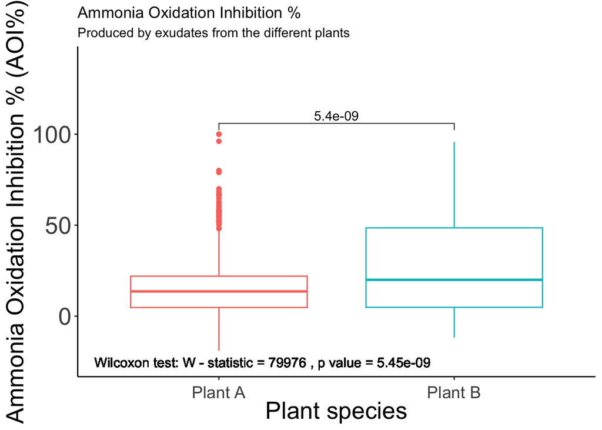

```r
# We will generate a box - plot and incorporate the result of the Wilcoxon test
library(ggplot2)
library(ggpubr)

AOIs_boxplot_plant <- ggplot(data_statistics, aes(x = Plant, y = AOI, col = Plant)) +
  geom_boxplot(aes(colour = Plant)) +
  theme_classic() +
  labs(title = "Ammonia Oxidation Inhibition %", subtitle = "Produced by exudates from the different plants", x = "Plant species", y = "Ammonia Oxidation Inhibition % (AOI%)") +
  theme(axis.title = element_text(size = 20), axis.text.y = element_text(size = 20), axis.text.x = element_text(size = 14, angle = 0, vjust = 0), legend.text = element_text(size = 20), legend.title = element_text(size = 20), legend.position = "none") +
  ylim(-25,140) +
  geom_text(x = -Inf, y = -Inf, label = paste("Wilcoxon test: W - statistic =", round(wilcox_test(data_statistics, AOI ~ Plant)$statistic,2), ", p value =", wilcox_test(data_statistics, AOI ~ Plant)$p), vjust = -1, hjust = -0.05, colour = "black", size = 4) +
  stat_compare_means(method = "wilcox.test", label = "p.format", comparisons = list(c("Plant A","Plant B")))

AOIs_boxplot_plant
```

```r
cairo_pdf("AOI values boxplot_plant.pdf", height = 8, width = 7)
print(AOIs_boxplot_plant)
dev.off()
```

**Section 3 : Data Visualisation - Heatmap**

Step 1: We will use the data in the second format. We can clear the environment and import the data

```r
# Clear environment
rm(list = ls())

# Import the data
library(readxl)
data_heatmap <- read_xlsx("data.xlsx", sheet = 2)

# Let's view the data
data_heatmap
```

```
## # A tibble: 77 × 6
##    Exudate `Strain A` `Strain B` `Strain C` `Strain D` Plant
##    <chr>        <dbl>      <dbl>      <dbl>      <dbl> <chr>
##  1 A1            9.98       4.92      14.8       42.4  Plant A
##  2 A2           32.3       23.7        4.75      19.1  Plant A
##  3 A3           32.4       18.1       31.3       33.9  Plant A
##  4 A4           20.7       18.4      -10.9       20.0  Plant A
##  5 A5           16.0       11.0       10.8       41.9  Plant A
##  6 A6           14.4       14.4        5.29      18.9  Plant A
##  7 A7           30.2       16.6        3.39       7.74 Plant A
##  8 A8           27.1       16.1      -13.7        6.36 Plant A
##  9 A9           31.1       27.9       -4.74      35.0  Plant A
## 10 A10          29.5       22.8       20.6       54.3  Plant A
## # ℹ 67 more rows
```

Step 2: The data need some pre-processing before they are valid for the package we will use to generate the heatmap

```r
# We will remove the exudate names and store them in a separate vector
library(dplyr)
root_exudates <- data_heatmap$Exudate
data_AOI <- select(data_heatmap, -Exudate)

# We will do the same with the Plant variable
data_AOI <- select(data_AOI, -Plant)

# We will turn the data frame into a matrix, and we will put the root exudate names as row names
data_AOI_mat <- as.matrix(data_AOI)
col_to_row_names <- root_exudates
rownames(data_AOI_mat) <- col_to_row_names

# Let's view the data now
data_AOI_mat
```

```
##        Strain A    Strain B     Strain C  Strain D
## A1    9.9848714  4.91803279  14.78666667 42.416667
## A2   32.3247605 23.69715272   4.74666667 19.066667
## A3   32.4256178 18.11044003  31.32666667 33.877853
## A4   20.7261725 18.36928387 -10.85333333 20.030000
## A5   16.0363086 10.98648260  10.84666667 41.863333
## A6   14.4225920 14.42335347   5.29000000 18.926667
## A7   30.2067574 16.58613747   3.39333333  7.736667
## A8   27.0801815 16.10296232 -13.70000000  6.355000
## A9   31.1144730 27.87748059  -4.74333333 34.953333
## A10  29.5007564 22.82714984  20.61666667 54.296667
## A11  11.3464448 11.86942767   8.68000000 55.536667
## A12  17.3474534 15.92464768   0.28519331 52.390340
## A13  15.9858800 14.96980155   0.09833477 48.938090
## A14  22.9450328 14.38021283   1.63000000 14.923333
## A15   9.6822995 12.70348001  -4.34000000 16.095000
## A16  17.4483106 14.84900777 -15.73333333 53.326667
## A17   0.7060010 12.19442048   7.19000000 66.036667
## A18   5.4462935  8.94449238  -0.56333333 15.610000
## A19  -0.4246815 23.60191117  -8.40666667 10.636667
## A20  71.3464901 43.43687087  -7.73000000  5.110000
## A21  -4.5382734 29.83775811   4.05537399 27.070058
## A22   9.3679740 11.30284728  -3.12000000 13.953333
## A23  12.5505871 11.30284728  -0.54333333 11.603333
## A24  18.8358731 15.81823411 -10.85000000  9.810000
## A25  13.9495378 15.53171642   4.88666667 10.226667
## A26  -2.3432426  6.72574627   1.97666667 20.896667
## A27 -11.1507492  4.83508005  -3.26585883 11.074114
## A28   9.1981014 51.59514925  -3.84333333 15.225000
## A29  23.0027479 18.18407960   0.25666667 17.616667
## A30  15.5933050 21.87500000  14.67333333 35.393333
## A31  12.0684487 25.04197761  15.20333333 32.246667
## A32  98.7099675 62.67412935   5.28333333 68.486667
## A33  18.4261804 17.82649254   9.64666667 32.796667
## A34  16.7149638 10.48041045  57.53000000 24.723333
## A35  13.6047964 16.84701493   3.69666667  6.673333
## A36  25.5208594 56.05099502  15.33666667 28.960000
## A37  -1.6868821 21.22098630   1.52662606 15.175638
## A38  -5.2310767  6.12873134   5.94333333 16.383333
## A39  -1.7278083  7.48947685 -15.69239775  6.972591
```

[output cut: 23 more lines]

```
## B27  83.3052900 35.35897712  91.07482772 74.367558
## B28  21.1557944  6.60848328  36.06318682 40.350852
## B30  -8.5848669 -2.63621018  37.28566773 16.187260
## B31  -2.0594548  0.73627124  93.82540977 55.247823
## B32  -4.9043335 -3.41558022  10.59483455 19.354333
## B33  -6.6304397 -5.22932155  24.24587136  8.914723
## B34   6.3427554  0.08574797  92.70480227 48.913678
## B35  37.0930179 16.06345350  93.01042250 61.933866
## B36  17.3386913 12.26553289   0.40550875 24.374659
## B37  52.7649664 25.58147844  91.54360030 68.080944
## B38   8.0825608  1.80070742  37.20542781 26.265796
## B39  -5.2057172  5.03412055   5.98125406 17.755678
## B40   2.4521668  7.78162850  42.37566437 51.480961
## B42   8.1601900  3.30844260  25.34429687 24.584785
## B44  48.6049591 18.71449498  10.74598187 50.535392
```

Step 3: We will create an initial heatmap

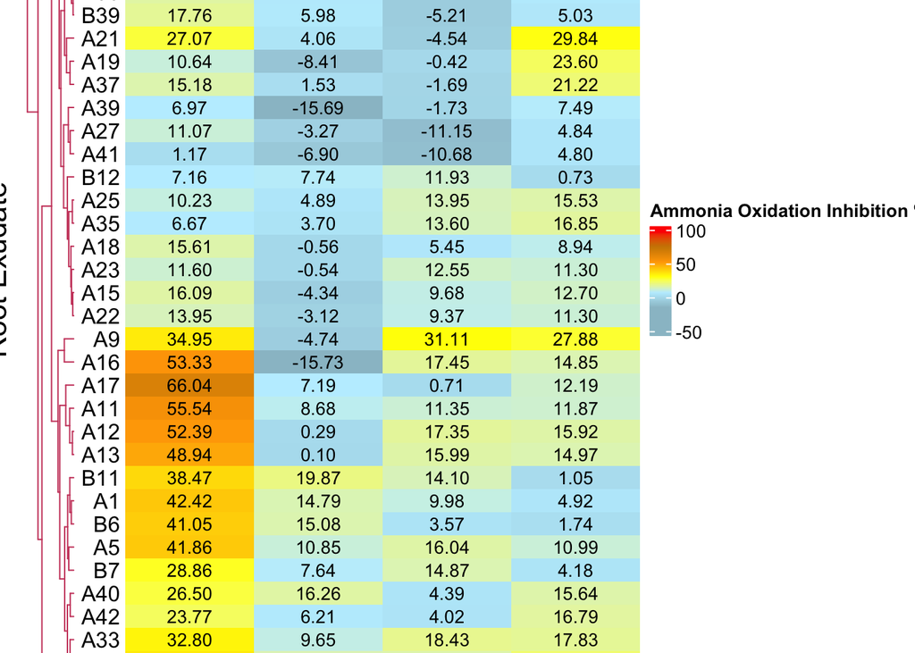

```r
library(ComplexHeatmap)
library(dendextend)

# These commands set the dendrogram for the rows (Root Exudates) and the columns (AOM Strains) of the heatmap, including the type of clustering (here hierarchical) and the type of distances calculated (here Euclidean distances). We also set the different colours for the different clusters. Here, for the initial heatmap we will set it to one colour
row_dend <- as.dendrogram(hclust(dist(data_AOI_mat, method = "euclidean"), method = "complete"))
row_dend <- colour_branches(row_dend, k = 1)
column_dend <- as.dendrogram(hclust(dist(data_AOI_mat, method = "euclidean"), method = "complete"))
column_dend <- colour_branches(column_dend, k = 1)

RE_AOI_heatmap <- Heatmap(data_AOI_mat, name = "Ammonia Oxidation Inhibition %",
        column_title = "AOM strains", column_title_side = "bottom", column_title_gp = gpar(fontsize = 16), column_dend_side = "bottom", column_names_gp = gpar(fontsize = 10),
        row_title = "Root Exudate", row_names_side = "left",  row_names_gp = gpar(fontsize = 12),   row_dend_width = unit(10,"mm"), row_title_gp = gpar(fontsize = 16),
        column_title_rot = 0, column_names_rot = 0, column_names_centered = T,
        col = c("lightblue3", "lightblue1", "yellow", "orange", "orange3", "red"),
        cluster_rows = row_dend, row_dend_gp = gpar(font = "bold"),
        border = F,
        column_km = 1,
        show_column_dend = T,
        width = ncol(data_AOI_mat)*unit(25,"mm"), height = nrow(data_AOI_mat)*unit(4.5,"mm"),
        cell_fun = function(j, i, x, y, width, height, fill) {
  grid.text(sprintf("%.2f", data_AOI_mat[i, j]), x, y, gp = gpar(fontsize = 10))
})

RE_AOI_heatmap
```

```r
cairo_pdf("Heatmap_initial.pdf", width = 8, height = 16)
RE_AOI_heatmap
dev.off()
```

Step 4: Based on this initial heatmap we will designate the clustering groups and also prepare an annotation on the right side indicating the plant species from which the root exudates originate

```r
# We will extract the clusters
row_order_clustered <- row_order(RE_AOI_heatmap)

# We will bind the matrix we use for the heatmap with the clustered order of the root exudates
data_clustered <- cbind(data_AOI_mat, row_order_clustered)

# We will create a data frame and go through some transformations. By the end, we will have sorted the root exudates with the order they appear on the heatmap (top to bottom). And they are accompanied by the plant they originate from
data_plant <- data.frame(cbind(data_heatmap$Exudate, data_heatmap$Plant))
plant_origin_ordered <- cbind(data_plant, seq(1,77,1))
colnames(plant_origin_ordered) <- c("Exudate","Plant","Number")
plant_origin_ordered <- mutate(plant_origin_ordered, Number = as.numeric(Number))
plant_origin_ordered$Number <- factor(plant_origin_ordered$Number, levels = row_order_clustered)
plant_origin_ordered <- plant_origin_ordered[order(plant_origin_ordered$Number), ]
view(plant_origin_ordered)

# We will extract the plant order to prepare the annotation on the right side of the heatmap
plant_order <- plant_origin_ordered$Plant
RE_order <- plant_origin_ordered$Exudate
```

Step 5: Now we will sort the matrix with the AOI values based on the order that the exudates appear on the heatmap

```r
library(tibble)
data_AOI_origin <- data_AOI_mat
data_AOI_origin <- data.frame(data_AOI_origin)
data_AOI_origin <- rownames_to_column(data_AOI_origin, var = "Exudate")

data_AOI_origin$Exudate <- factor(data_AOI_origin$Exudate, levels = RE_order)
data_AOI_origin <- data_AOI_origin[order(data_AOI_origin$Exudate), ]
data_AOI_origin <- cbind(seq(1,77,1), data_AOI_origin)
rownames(data_AOI_origin) <- data_AOI_origin$"seq(1, 77, 1)"
rownames(data_AOI_origin) <- data_AOI_origin$Exudate
data_AOI_origin <- data_AOI_origin[,-c(1:2)]

data_AOI_origin_mat <- as.matrix(data_AOI_origin)

data_AOI_origin_mat
```

```
##        Strain.A    Strain.B     Strain.C  Strain.D
## B27  83.3052900 35.35897712  91.07482772 74.367558
## B3   59.7277893 18.08713142  94.43665022 81.288199
## B37  52.7649664 25.58147844  91.54360030 68.080944
## B31  -2.0594548  0.73627124  93.82540977 55.247823
## B34   6.3427554  0.08574797  92.70480227 48.913678
## B15  28.9785491  6.15594584  93.31604272 68.385310
## B10  46.2714179 14.76852351  94.74227045 66.508526
## B35  37.0930179 16.06345350  93.01042250 61.933866
## A32  98.7099675 62.67412935   5.28333333 68.486667
## A20  71.3464901 43.43687087  -7.73000000  5.110000
## A4   20.7261725 18.36928387 -10.85333333 20.030000
## A8   27.0801815 16.10296232 -13.70000000  6.355000
## A24  18.8358731 15.81823411 -10.85000000  9.810000
## A14  22.9450328 14.38021283   1.63000000 14.923333
## A29  23.0027479 18.18407960   0.25666667 17.616667
## A6   14.4225920 14.42335347   5.29000000 18.926667
## B36  17.3386913 12.26553289   0.40550875 24.374659
## A2   32.3247605 23.69715272   4.74666667 19.066667
## A7   30.2067574 16.58613747   3.39333333  7.736667
## A28   9.1981014 51.59514925  -3.84333333 15.225000
## A36  25.5208594 56.05099502  15.33666667 28.960000
## B33  -6.6304397 -5.22932155  24.24587136  8.914723
## A43   0.5945541  7.28233831  17.45666667 13.236667
## B32  -4.9043335 -3.41558022  10.59483455 19.354333
## A44 -11.7786660  9.00652985   3.82666667 27.730000
## A26  -2.3432426  6.72574627   1.97666667 20.896667
## A38  -5.2310767  6.12873134   5.94333333 16.383333
## B39  -5.2057172  5.03412055   5.98125406 17.755678
## A21  -4.5382734 29.83775811   4.05537399 27.070058
## A19  -0.4246815 23.60191117  -8.40666667 10.636667
## A37  -1.6868821 21.22098630   1.52662606 15.175638
## A39  -1.7278083  7.48947685 -15.69239775  6.972591
## A27 -11.1507492  4.83508005  -3.26585883 11.074114
## A41 -10.6818877  4.79971710  -6.89970474  1.171864
## B12  11.9279390  0.72549653   7.74237909  7.155238
## A25  13.9495378 15.53171642   4.88666667 10.226667
## A35  13.6047964 16.84701493   3.69666667  6.673333
## A18   5.4462935  8.94449238  -0.56333333 15.610000
## A23  12.5505871 11.30284728  -0.54333333 11.603333
```

[output cut: 23 more lines]

```
## B17  39.0565124  6.89940021  48.79736295 63.106855
## B20  43.6902612 17.95783500  37.59128795 52.549947
## B14  15.3327754  2.20522214  61.83715932 51.025060
## B24  15.6631282  5.43404087  52.36293227 51.142359
## B21  -7.6201383  2.70804152  37.99878159 48.913678
## B40   2.4521668  7.78162850  42.37566437 51.480961
## B4   -0.6166586  2.52128003  52.66855250 30.263139
## B19   1.0483196  5.88657831  61.42966568 17.829446
## A34  16.7149638 10.48041045  57.53000000 24.723333
## B13  14.5927851 -0.59979169  49.71422363 16.539157
## B38   8.0825608  1.80070742  37.20542781 26.265796
## B42   8.1601900  3.30844260  25.34429687 24.584785
## B30  -8.5848669 -2.63621018  37.28566773 16.187260
## B5   -6.8228868  4.44635995  47.88050227 20.410024
## B9   -6.7436022 -0.93021585  47.98237568 15.835363
```

Step 6: We will designate the annotation and prepare the final heatmap

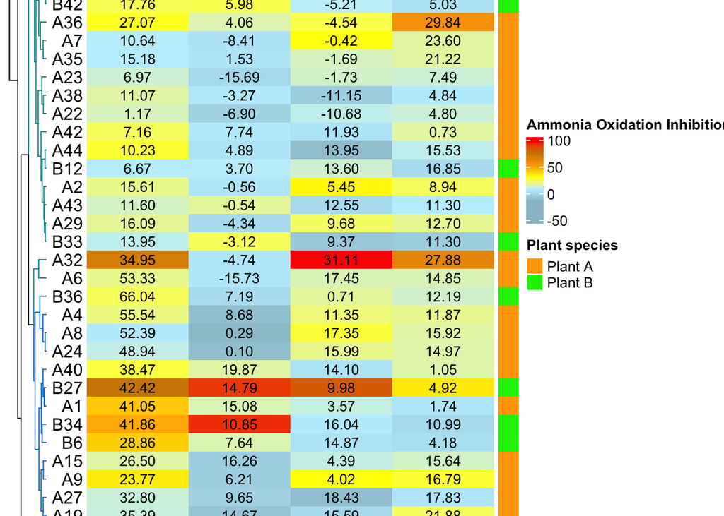

```r
library(ComplexHeatmap)
library(dendextend)

# we will designate the type of annotation and the colours of the different plant species
row_ha_Origin = rowAnnotation("Plant species" = plant_order, col = list("Plant species" = c("Plant A" = "orange", "Plant B" = "green2")))

# We will re - designate the cluster number based on the initial heatmap
row_dend <- as.dendrogram(hclust(dist(data_AOI_mat, method = "euclidean"), method = "complete"))
row_dend <- colour_branches(row_dend, k = 13)
column_dend <- as.dendrogram(hclust(dist(data_AOI_mat, method = "euclidean"), method = "complete"))
column_dend <- colour_branches(column_dend, k = 1)

RE_AOI_heatmap_final <- Heatmap(data_AOI_origin_mat, name = "Ammonia Oxidation Inhibition %",  right_annotation = row_ha_Origin,
        column_title = "AOM strains", column_title_side = "bottom", column_title_gp = gpar(fontsize = 16), column_dend_side = "bottom", column_names_gp = gpar(fontsize = 10),
        row_title = "Root Exudate", row_names_side = "left",  row_names_gp = gpar(fontsize = 12),   row_dend_width = unit(10,"mm"), row_title_gp = gpar(fontsize = 16),
        column_title_rot = 0, column_names_rot = 0, column_names_centered = T,
        col = c("lightblue3", "lightblue1", "yellow", "orange", "orange3", "red"),
        cluster_rows = row_dend, row_dend_gp = gpar(font = "bold"),
        border = F,
        column_km = 1,
        show_column_dend = T,
        width = ncol(data_AOI_mat)*unit(25,"mm"), height = nrow(data_AOI_mat)*unit(4.5,"mm"),
        cell_fun = function(j, i, x, y, width, height, fill) {
  grid.text(sprintf("%.2f", data_AOI_mat[i, j]), x, y, gp = gpar(fontsize = 10))
})

RE_AOI_heatmap_final
```

```r
cairo_pdf("Heatmap_final_annotated.pdf", width = 8, height = 16)
RE_AOI_heatmap_final
dev.off()
```

**Section 4 : Data Visualisation - PCA**

Step 1: We will use the data in the second format. We can clear the environment and re - import the data

```r
# Clear environment
rm(list = ls())

# Import the data
library(readxl)
data_PCA <- read_xlsx("data.xlsx", sheet = 2)

# Let's view the data
data_PCA
```

```
## # A tibble: 77 × 6
##    Exudate `Strain A` `Strain B` `Strain C` `Strain D` Plant
##    <chr>        <dbl>      <dbl>      <dbl>      <dbl> <chr>
##  1 A1            9.98       4.92      14.8       42.4  Plant A
##  2 A2           32.3       23.7        4.75      19.1  Plant A
##  3 A3           32.4       18.1       31.3       33.9  Plant A
##  4 A4           20.7       18.4      -10.9       20.0  Plant A
##  5 A5           16.0       11.0       10.8       41.9  Plant A
##  6 A6           14.4       14.4        5.29      18.9  Plant A
##  7 A7           30.2       16.6        3.39       7.74 Plant A
##  8 A8           27.1       16.1      -13.7        6.36 Plant A
##  9 A9           31.1       27.9       -4.74      35.0  Plant A
## 10 A10          29.5       22.8       20.6       54.3  Plant A
## # ℹ 67 more rows
```

Step 2: The data need some pre - processing

```r
# We need to keep only the AOI values
library(dplyr)
data_mat <- select(data_PCA, -c(Exudate, Plant))

# We need to scale our data
library(vegan)
data_standardised <- scale(data_mat, center = TRUE, scale = TRUE)

# We will use the root exudates as row names in the matrix
rownames(data_standardised) <- data_PCA$Exudate

# Let's inspect the matrix
data_standardised
```

```
##         Strain A    Strain B    Strain C    Strain D
## A1  -0.290765011 -0.68130953 -0.24931935  0.52007412
## A2   0.768044123  0.80163446 -0.57437132 -0.63579409
## A3   0.772824300  0.36046459  0.28617464  0.09738702
## A4   0.218323805  0.38090489 -1.07943215 -0.58810731
## A5  -0.003954411 -0.20209798 -0.37687958  0.49268309
## A6  -0.080437237  0.06930383 -0.55678052 -0.64272435
## A7   0.667660413  0.24009391 -0.61818642 -1.19665006
## A8   0.519474936  0.20193868 -1.17159496 -1.26504511
## A9   0.710682003  1.13174535 -0.88161666  0.15062531
## A10  0.634199176  0.73293233 -0.06056905  1.10815610
## A11 -0.226232626 -0.13237383 -0.44702692  1.16953839
## A12  0.058187886  0.18785758 -0.71881462  1.01378941
## A13 -0.006344499  0.11245558 -0.72486429  0.84289662
## A14  0.323487692  0.06589711 -0.67527556 -0.84089676
## A15 -0.305105541 -0.06651063 -0.86855846 -0.78289709
## A16  0.062968063  0.10291677 -1.23742554  1.06013931
## A17 -0.730541266 -0.10670990 -0.49526670  1.68930782
## A18 -0.505872962 -0.36334926 -0.74628625 -0.80690549
## A19 -0.784130473  0.79411345 -1.00021962 -1.05309469
## A20  2.617496629  2.36043468 -0.97831206 -1.32667492
## A21 -0.979096019  1.28654397 -0.59675240 -0.23961143
## A22 -0.320003142 -0.17711538 -0.82906011 -0.88891355
## A23 -0.169161759 -0.17711538 -0.74563874 -1.00524290
## A24  0.128732212  0.17945435 -1.07932423 -1.09401622
## A25 -0.102857854  0.15682870 -0.56983872 -1.07339045
## A26 -0.875061542 -0.53855854 -0.66405199 -0.54520570
## A27 -1.292497296 -0.68786011 -0.83378239 -1.03144021
## A28 -0.328054330  3.00467520 -0.85247853 -0.82596370
## A29  0.326223128  0.36627973 -0.71973819 -0.70757177
## A30 -0.024950766  0.65774324 -0.25298859  0.17240612
## A31 -0.192012926  0.90783219 -0.23582947  0.01664030
## A32  3.914401002  3.87955682 -0.55699636  1.81058736
## A33  0.109314640  0.33804190 -0.41573042  0.04386632
## A34  0.028210757 -0.24206133  1.13452575 -0.35577862
## A35 -0.119197031  0.26069481 -0.60836580 -1.24928702
## A36  0.445570156  3.35654311 -0.23151271 -0.14605578
## A37 -0.843953040  0.60609728 -0.67862237 -0.82840719
## A38 -1.011931745 -0.58570344 -0.53562840 -0.76862406
## A39 -0.845892758 -0.47824849 -1.23610022 -1.23447324
```

[output cut: 29 more lines]

```
## B34 -0.463384746 -1.06290396  2.27333439  0.84168820
## B35  0.994037841  0.19881876  2.28322906  1.48621158
## B36  0.057772603 -0.10109431 -0.71491932 -0.37303864
## B37  1.736816919  0.95043534  2.23573967  1.79050335
## B38 -0.380925880 -0.92747755  0.47650361 -0.27942385
## B39 -1.010729819 -0.67214234 -0.53440069 -0.70069044
## B40 -0.647780951 -0.45517795  0.64389361  0.96877346
## B42 -0.377246613 -0.80841517  0.09249126 -0.36263700
## B44  1.539651494  0.40816542 -0.38013932  0.92196606
## attr(,"scaled:center")
## Strain A Strain B Strain C Strain D
## 16.11974 13.54573 22.48749 31.91051
## attr(,"scaled:scale")
## Strain A Strain B Strain C Strain D
## 21.09907 12.66340 30.88737 20.20127
```

Step 3: Let’s perform the PCA

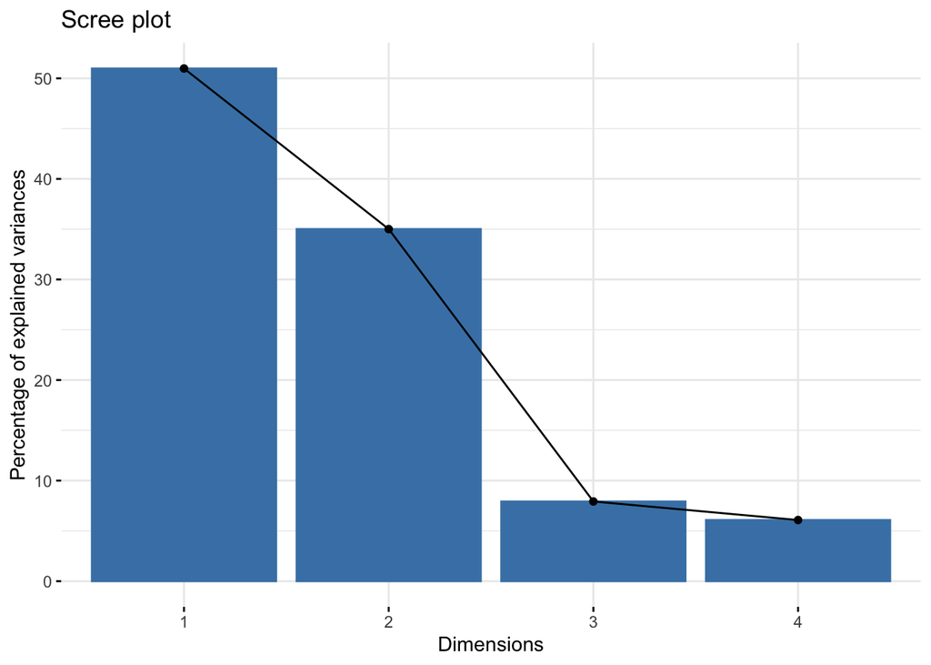

```r
library(factoextra)

# We compute the PCA and extract the data
pca <- prcomp(data_standardised, scale. = TRUE)
pca_data <- as.data.frame(pca$x)

# We can inspect the Eigenvalues to see if our principal components explain a sufficient amount of the original variation
fviz_eig(pca)
```

```r
get_eigenvalue(pca)
```

```
##       eigenvalue variance.percent cumulative.variance.percent
## Dim.1  2.0392017        50.980043                    50.98004
## Dim.2  1.4004324        35.010810                    85.99085
## Dim.3  0.3170889         7.927223                    93.91808
## Dim.4  0.2432769         6.081923                   100.00000
```

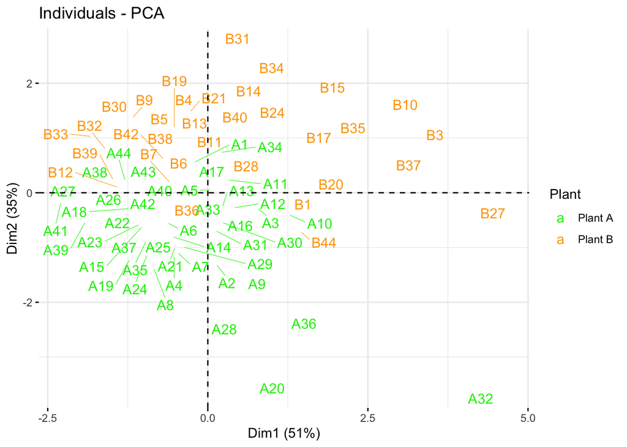

```r
# We will enter also the Plant variable in order to perform some clustering later
pca_data <- mutate(pca_data, Plant = data_PCA$Plant)

# We will plot first a simple PCA
REs_PCA_plot <- fviz_pca_ind(pca,
                             habillage = as.factor(pca_data$Plant),
                             addEllipses = F,
                             repel = T, geom = "text",
                             legend.title = "Plant",
                             palette = c("green2", "orange"))
REs_PCA_plot
```

```r
cairo_pdf("PCA_simple.pdf", width = 8, height = 8)
REs_PCA_plot
dev.off()
```

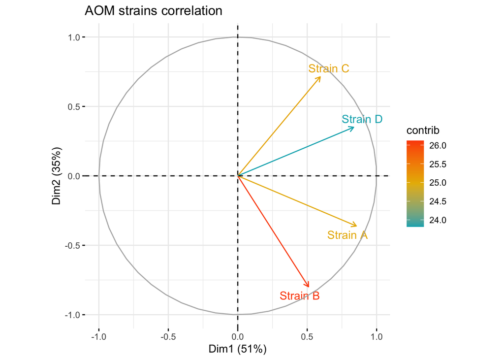

```r
# We will now investigate the contribution and correlation between the different variables (here the 4 AOM Strains)
REs_strain_correlation_plot <- fviz_pca_var(pca,
                                            col.var = "contrib",
                                            gradient.cols = c("#00AFBB", "#E7B800", "#FC4E07"),
                                            repel = TRUE,
                                            title = "AOM strains correlation")
REs_strain_correlation_plot
```

```r
cairo_pdf("PCA_variables.pdf", width = 8, height = 8)
REs_strain_correlation_plot
dev.off()
```

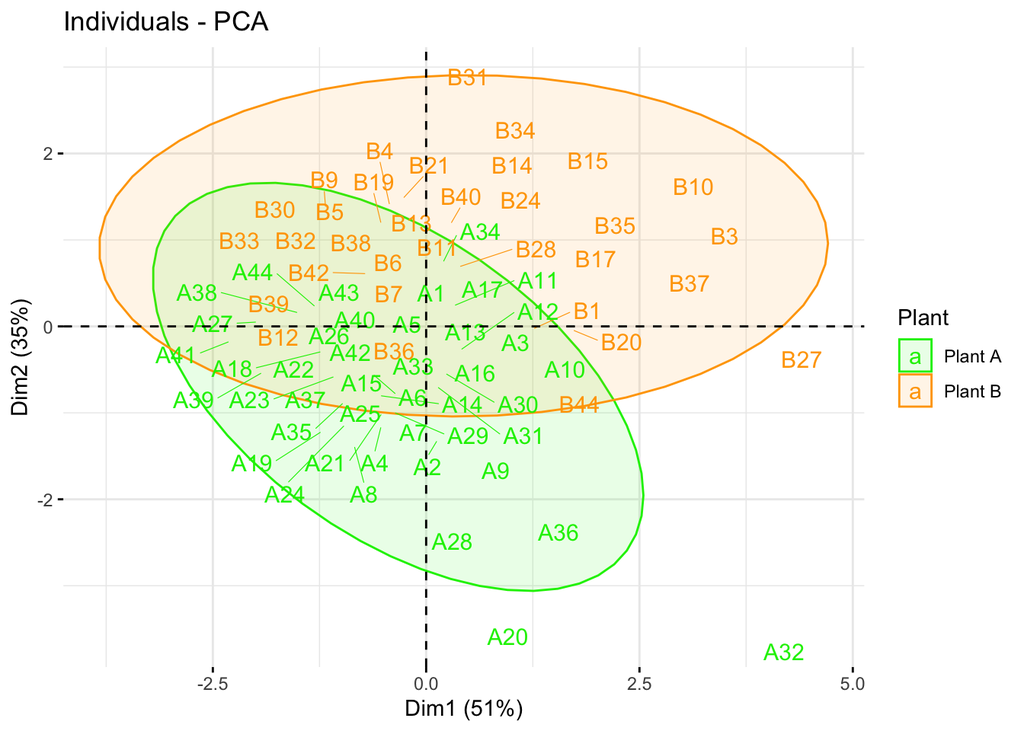

```r
# We can try and investigate any clustering due to the plant species, so we will generate the PCA plot, insert ellipses and complement with a PERMANOVA
REs_PCA_plot_elipses <- fviz_pca_ind(pca,
                                     habillage = as.factor(pca_data$Plant),
                                     addEllipses = T,
                                     repel = T, geom = "text",
                                     legend.title = "Plant",
                                     palette = c("green2", "orange"))
REs_PCA_plot_elipses
```

```r
data_standardised_permanova <- cbind(data.frame(data_standardised), data_PCA$Plant)
adonis2(data_standardised_permanova[,1:4] ~ data_PCA$Plant, method= 'euc')
```

```
## Permutation test for adonis under reduced model
## Permutation: free
## Number of permutations: 999
##
## adonis2(formula = data_standardised_permanova[, 1:4] ~ data_PCA$Plant, method = "euc")
##          Df SumOfSqs      R2     F Pr(>F)
## Model     1   62.551 0.20576 19.43  0.001 ***
## Residual 75  241.449 0.79424
## Total    76  304.000 1.00000
## ---
## Signif. codes:  0 '***' 0.001 '**' 0.01 '*' 0.05 '.' 0.1 ' ' 1
```

```r
cairo_pdf("PCA_ellipses.pdf", width = 8, height = 8)
REs_PCA_plot_elipses
dev.off()
```

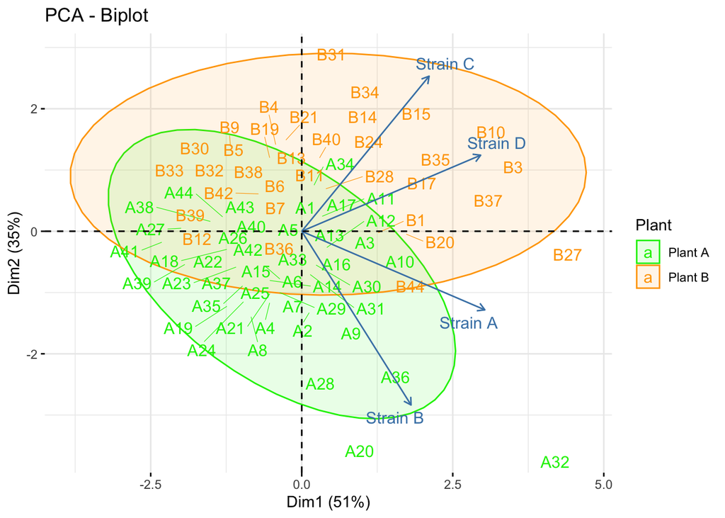

```r
# Finally we can generate a bi-plot with the ellipses and the variable vectors
REs_biplot <- fviz_pca_biplot(pca,
                              habillage = as.factor(pca_data$Plant),
                              addEllipses = T, ellipse.level = 0.95,
                              legend.title = "Plant",
                              repel = T,
                              geom = "text",
                              palette = c("green2", "orange"))
REs_biplot
```

```r
cairo_pdf("PCA_biplot.pdf", width = 8, height = 8)
print(REs_biplot)
dev.off()
```

This is the end. We have analysed the data, starting investigating the mean activity of all exudates against the 2 domains and the 4 strains of AOM, as well as the effect of the 2 different plant species. Then, through the inhibition plots, we investigated the variation in the activity of each exudate separately. Finally, we visualised our data, using a heatmap and a PCA, to discover distinct inhibitory activity patterns.

Thanks a lot for using this code!

Remember to always cite the author of the code you use!

And buy a programmer a beer 🍺 ! They really need one!